# R Prediction Starter

John Young

March 13, 2017

## Let’s open the files and EDA

Read with `readr` package which is fast.

Let’s take a quick peak at the data from train and test.

```
## Source: local data frame [6 x 8]
##
##      Id    region       date     O3  PM10  PM25   NO2     T2M
##   <int>     <chr>     <date>  <dbl> <dbl> <dbl> <dbl>   <dbl>
## 1     1 E12000001 2007-01-02 42.358 9.021    NA    NA 278.138
## 2     2 E12000001 2007-01-03 49.506 5.256    NA    NA 281.745
## 3     3 E12000001 2007-01-04 51.101 4.946    NA    NA 280.523
## 4     4 E12000001 2007-01-05 47.478 6.823    NA    NA 280.421
## 5     5 E12000001 2007-01-06 45.226 7.532    NA    NA 278.961
## 6     6 E12000001 2007-01-07 53.226 5.607    NA    NA 281.504
```

```
## Source: local data frame [6 x 8]
##
##      Id    region       date     O3   PM10   PM25    NO2     T2M
##   <int>     <chr>     <date>  <dbl>  <dbl>  <dbl>  <dbl>   <dbl>
## 1 18404 E12000006 2012-05-28 75.980 20.876 19.123  9.713 290.787
## 2 18405 E12000006 2012-05-29 73.084 21.660 17.794  8.417 288.474
## 3 18406 E12000006 2012-05-30 59.350 21.925 17.699 10.878 289.889
## 4 18407 E12000006 2012-05-31 45.991 14.549 11.386 10.302 287.815
## 5 18408 E12000006 2012-06-01 52.210 11.208  9.545  8.598 287.627
## 6 18409 E12000006 2012-06-02 68.120 10.118  7.838  6.656 286.108
```

There are a number of things we can do to prep and clean up the data for an initial prediction of mortality-rate.

- Region might be able to be broken down further.
- Date can be broken into month day year
- Missing values in train (may need to impute)
- log transformations of a few variables and the target
- new features mean and medians by region, month, day, year

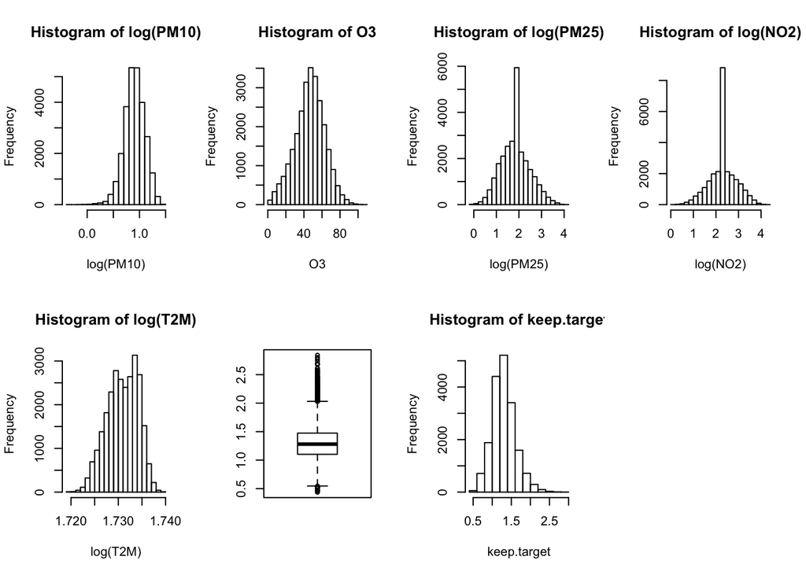

Let’s look at the new full feature set of data.

```
##   Id     O3     PM10 PM25    NO2      T2M RM_med  RM_mean
## 1  1 42.358 2.199555 6.81 10.628 5.628117 1.9395 1.970167
## 2  2 49.506 1.659370 6.81 10.628 5.641002 1.9425 1.949333
## 3  3 51.101 1.598579 6.81 10.628 5.636656 1.8805 1.937500
## 4  4 47.478 1.920299 6.81 10.628 5.636292 1.9395 1.976667
## 5  5 45.226 2.019161 6.81 10.628 5.631072 1.9195 1.937333
## 6  6 53.226 1.724016 6.81 10.628 5.640147 1.8505 1.989000
```

```
##          Id     O3     PM10   PM25    NO2      T2M RM_med RM_mean
## 26284 26284 50.526 2.172818  4.582  7.173 5.630990  1.837  1.7094
## 26285 26285 57.951 1.859730  3.683  6.082 5.625280  2.036  1.9310
## 26286 26286 41.479 2.694762 10.989 14.361 5.617531  1.894  1.9936
## 26287 26287 32.742 2.874807 12.177 17.386 5.619574  1.951  1.8738
## 26288 26288 39.006 2.833037 10.754 15.317 5.622084  1.992  1.8864
## 26289 26289 51.444 2.919823  9.248  8.701 5.636606  1.741  1.7248
```

We can also see the correlation matrix with significance showing PM10 and PM25.

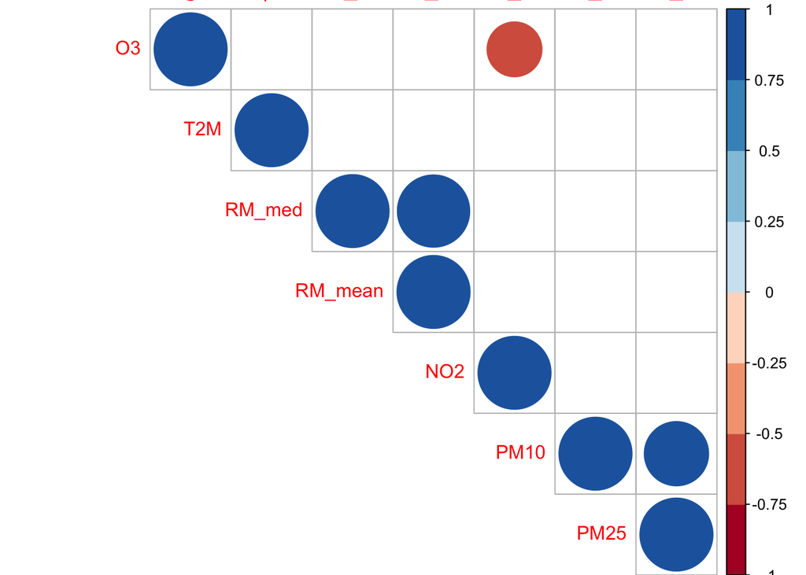

### Prepare the data

Before proceeding the data frame will be stored as a *sparse matrix*. The MORTALITY_RATE column will be treated as a target variable and therefore removed from the matrix:

Data will be stored using `DGMatrix` class, which is a recommended way

# Training and Tuning

Training is done using 5-fold CV, which is a common place to begin with cross validation. If your TEST set is a % of your TRAINING, you may want to consider replicating that split with your TRAINING only. That way you have the actual results when you predict on TEST and can see where your algorithms are underperforming or overfitting.

```r
################# Loop 5x initially to see where the values converge, then 50
# Automated to run and may take a long time.
#####################
nloops<-20 # Set this for the number of random loops
best_param = list() # You will store your best set of parameters here
best_seednumber = 1969 # Initialize to same number for starters
best_error = Inf # Set to infinity for starters
best_error_index = 0
best_history<-NULL
cv.nround = 500 # Set to number of rounds you'd like it to fit - usually higher
cv.nfold = 5 # 5-Fold Validation
cv.earlystop = 5 # Stop after consecutive rounds of no improvement

for (iter in 1:nloops) {
  param <- list(objective = "reg:linear", # Objective for the algorithm
                #booster="gblinear", # Make sure this aligns to your objective
                eval_metric="rmse",
                max_depth = sample(1:20, 1), # Range 8-11 common 8
                eta = runif(1, .5, .9), # Range .1-.3, common 0.8
                gamma = runif(1, 0.0, 0.2), # Range 0-.2
                subsample = runif(1, .6, .9), # Range 0.6-0.9 common 0.7
                colsample_bytree = runif(1, .5, .8), # Range .5-.8 common 0.7
                min_child_weight = sample(1:40, 1), # Range 1-40
                max_delta_step = sample(1:10, 1) # Range 1-10
  )
  seed.number = sample.int(10000, 1)[[1]]
  set.seed(seed.number)
  history <- xgb.cv(data=dtrain,
                 params = param,
                 #watchlist = watchlist,
                 nfold=cv.nfold,
                 nrounds=cv.nround,
                 verbose = F, # Change to T if you'd like to see it learn
                 early.stop.round=cv.earlystop,
                 #feval=rmpse, # custom evaluation metric function call
                 maximize=FALSE)
  huh<-as.data.frame(history$test.rmse.mean)
  m_error = min(huh) # Make sure you change this if using a different function or err name
  m_error_index = which(huh==min(huh)) # Sets the number of rounds

  if (m_error < best_error) {
    best_error = m_error
    best_error_index = m_error_index
    best_seednumber = seed.number
    best_param = param
    best_history = history
  }
  cat("  Loop:", iter,"  Error:",m_error,"\n"); # Shows which random iteration you are on
}
```

```
## Stopping. Best iteration: 6  Loop: 1   Error: 0.178127
## Stopping. Best iteration: 5  Loop: 2   Error: 0.177623
## Stopping. Best iteration: 4  Loop: 3   Error: 0.183305
## Stopping. Best iteration: 7  Loop: 4   Error: 0.17174
## Stopping. Best iteration: 3  Loop: 5   Error: 0.181307
## Stopping. Best iteration: 3  Loop: 6   Error: 0.1769
## Stopping. Best iteration: 5  Loop: 7   Error: 0.17551
## Stopping. Best iteration: 9  Loop: 8   Error: 0.174736
## Stopping. Best iteration: 5  Loop: 9   Error: 0.180189
## Stopping. Best iteration: 5  Loop: 10   Error: 0.17293
## Stopping. Best iteration: 4  Loop: 11   Error: 0.175001
## Stopping. Best iteration: 4  Loop: 12   Error: 0.17653
## Stopping. Best iteration: 7  Loop: 13   Error: 0.173776
## Stopping. Best iteration: 7  Loop: 14   Error: 0.179182
## Stopping. Best iteration: 5  Loop: 15   Error: 0.181325
## Stopping. Best iteration: 36  Loop: 16   Error: 0.171005
## Stopping. Best iteration: 8  Loop: 17   Error: 0.177696
## Stopping. Best iteration: 2  Loop: 18   Error: 0.177183
## Stopping. Best iteration: 7  Loop: 19   Error: 0.175964
## Stopping. Best iteration: 5  Loop: 20   Error: 0.187419
```

```r
############################################
# END XGBoost Tuning
############################################
```

```
## Best round: 36
```

```
## Best result: 0.171005
```

## Hyperparameter tuning results

The results of tuning the parameters is visualized on the following plot:

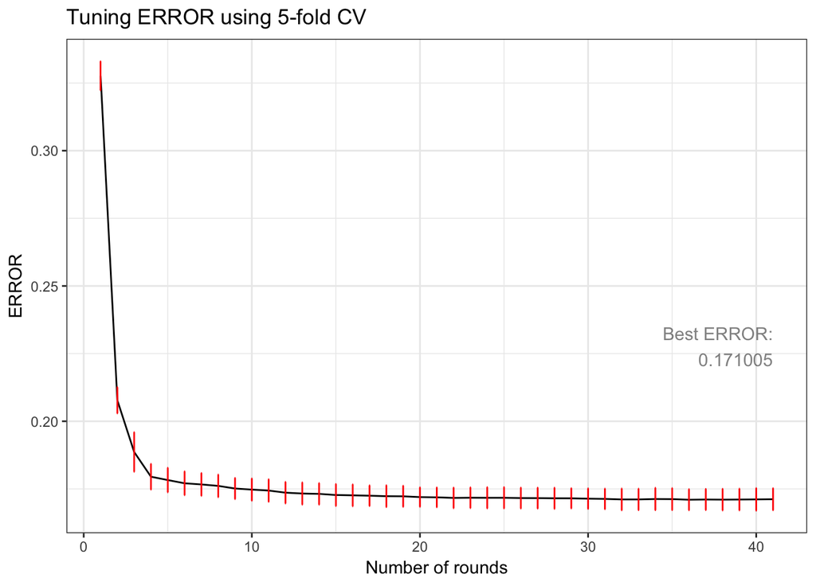

## Train XGBoost

```r
######################################
# Train XGB Model
######################################
train.full.sparse <- sparse.model.matrix(target~., data=train.full)
dtrain <- xgb.DMatrix(
  data=train.full.sparse,
  label=keep.target,
  missing = NaN)
dtest <-data.matrix(test.full, rownames.force = NA)

clf <- xgb.train(   params              = best_param,
                    data                = dtrain,
                    nrounds             = best_error_index,
                    verbose             = F,
                    maximize            = FALSE
)
```

## Make predictions and generate a Submission File

```r
##########################
# Begin Predictions on Test Data
##########################

# Make XGB Predictions
pred.xgb <- rep(0,nrow(test.full))
pred.xgb <- round(predict(clf, dtest),10)
# store in frame, may be able to add other models to ensemble later
airqualitypred <- data.frame(Id=keep.id, mortality_rate=pred.xgb)
###################################################################
# Write out submission files
write.csv(data.frame("Id"=airqualitypred$Id, "mortality_rate"=airqualitypred$mortality_rate), "~/Desktop/Data/Kaggle/AirQuality/baseXGB.csv", row.names = F)
```